# WL2_Single_Time_Surv

##### Hand calculated model output

```r
posterior::summarize_draws(r_pops) %>%
  mutate(across(mean:q95, inv_logit_scaled))
```

```
## # A tibble: 6 × 10
##   variable           mean median    sd   mad    q5   q95  rhat ess_bulk ess_tail
##   <chr>             <dbl>  <dbl> <dbl> <dbl> <dbl> <dbl> <dbl>    <dbl>    <dbl>
## 1 r_Other_Parent[B… 0.819  0.799 0.723 0.701 0.549 0.962  1.00    9149.    6885.
## 2 r_Other_Parent[D… 0.769  0.753 0.727 0.700 0.435 0.949  1.00    9760.    7014.
## 3 r_Other_Parent[L… 0.605  0.610 0.642 0.639 0.364 0.795  1.00    8827.    8596.
## 4 r_Other_Parent[S… 0.767  0.750 0.720 0.695 0.449 0.947  1.00    9022.    7243.
## 5 r_Other_Parent[T… 0.538  0.546 0.662 0.663 0.268 0.768  1.00    6970.    7831.
## 6 r_Other_Parent[W… 0.936  0.911 0.847 0.795 0.681 0.997  1.00    3916.    4771.
```

```r
#estimates seem to be a little off...
```

##### Tidybayes tables

```r
tibble(Other_Parent = "BH") %>%
  add_epred_draws(surv_parent_binary_m4) %>%
  median_qi(.epred) #median matches above chunk
```

```
## # A tibble: 1 × 8
##   Other_Parent  .row .epred .lower .upper .width .point .interval
##   <chr>        <int>  <dbl>  <dbl>  <dbl>  <dbl> <chr>  <chr>
## 1 BH               1  0.799  0.490  0.976   0.95 median qi
```

```r
tibble(Other_Parent = "BH") %>%
  add_epred_draws(surv_parent_binary_m4) %>%
  mean_qi(.epred) #mean does not match above chunk
```

```
## # A tibble: 1 × 8
##   Other_Parent  .row .epred .lower .upper .width .point .interval
##   <chr>        <int>  <dbl>  <dbl>  <dbl>  <dbl> <chr>  <chr>
## 1 BH               1  0.783  0.490  0.976   0.95 mean   qi
```

```r
tibble(Other_Parent = "WV") %>%
  add_epred_draws(surv_parent_binary_m4) %>%
  mean_qi(.epred) #mean does not match above chunk
```

```
## # A tibble: 1 × 8
##   Other_Parent  .row .epred .lower .upper .width .point .interval
##   <chr>        <int>  <dbl>  <dbl>  <dbl>  <dbl> <chr>  <chr>
## 1 WV               1  0.883  0.640  0.999   0.95 mean   qi
```

##### Tidy Plot

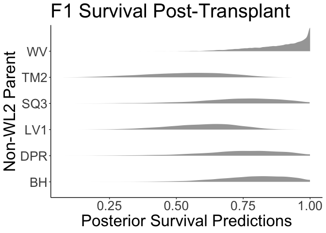

```r
wl2_surv_wl2F1s %>%
  data_grid(Other_Parent) %>%
  add_epred_draws(surv_parent_binary_m4) %>%
  ggplot(aes(y = Other_Parent, x = .epred)) +
  stat_slab() +
  theme_classic() +
  labs(x="Posterior Survival Predictions", y="Non-WL2 Parent", title="F1 Survival Post-Transplant") +
  theme(text=element_text(size=25))
```

```r
ggsave("../output/WL2_Traits/F1s_SurvPostTrans_PostProb.png", width = 8, height = 6, units = "in")
```

## F2s

```r
wl2_surv_F2 <- wl2_surv %>%
  filter(Pop.Type=="F2") %>%
  unite(Field_Loc, bed:col, sep="_") %>%
  mutate(WL2.cross = if_else(str_detect(parent.pop, "WL2"), TRUE, FALSE)) %>%
  select(WL2.cross, Pop.Type:parent.pop, Field_Loc, unique.ID:Surv_Post_Transplant, survey.notes) %>%
  separate_wider_delim(parent.pop, ") x (", names = c("maternal.pops", "paternal.pops"), cols_remove = FALSE) %>%
  mutate(maternal.pops=str_remove(maternal.pops, "\\("), paternal.pops=str_remove(paternal.pops, "\\)"))
wl2_surv_F2
```

```
## # A tibble: 435 × 11
##    WL2.cross Pop.Type maternal.pops paternal.pops parent.pop Field_Loc unique.ID
##    <lgl>     <chr>    <chr>         <chr>         <chr>      <chr>     <chr>
##  1 TRUE      F2       WL2 x BH      WL2 x TM2     (WL2 x BH… C_28_C    251
##  2 TRUE      F2       TM2 x WL2     SQ3 x WL2     (TM2 x WL… D_37_D    312
##  3 TRUE      F2       WL2 x TM2     CC x TM2      (WL2 x TM… H_30_D    263
##  4 TRUE      F2       WL2 x TM2     CC x TM2      (WL2 x TM… D_55_A    254
##  5 TRUE      F2       WL1 x TM2     WL2 x TM2     (WL1 x TM… D_52_B    326
##  6 TRUE      F2       WL1 x TM2     WL2 x TM2     (WL1 x TM… E_48_C    328
##  7 TRUE      F2       TM2 x WL2     YO11 x WL2    (TM2 x WL… F_17_B    377
##  8 TRUE      F2       TM2 x WL2     TM2           (TM2 x WL… C_28_B    347
##  9 TRUE      F2       WL2 x DPR     TM2 x WL2     (WL2 x DP… C_42_A    1314
## 10 TRUE      F2       WL2 x BH      SQ3 x WL2     (WL2 x BH… C_7_C     1172
## # ℹ 425 more rows
## # ℹ 4 more variables: death.date <chr>, Surv_to_Oct <dbl>,
## #   Surv_Post_Transplant <dbl>, survey.notes <chr>
```

### Calculate yes/no for each parent

```r
wl2_surv_F2_binary <- wl2_surv_F2 %>%
  filter(WL2.cross=="TRUE") %>% #if want TM2 F1s just # this out
  mutate(WL2=if_else(str_detect(parent.pop, "WL2"), 1, 0),
         CC=if_else(str_detect(parent.pop, "CC"), 1, 0),
         BH=if_else(str_detect(parent.pop, "BH"), 1, 0),
         WV=if_else(str_detect(parent.pop, "WV"), 1, 0),
         LV1=if_else(str_detect(parent.pop, "LV1"), 1, 0),
         TM2=if_else(str_detect(parent.pop, "TM2"), 1, 0),
         SQ3=if_else(str_detect(parent.pop, "SQ3"), 1, 0),
         DPR=if_else(str_detect(parent.pop, "DPR"), 1, 0),
         YO11=if_else(str_detect(parent.pop, "YO11"), 1, 0),
         maternal.WL2=if_else(str_detect(maternal.pops, "WL2"), 1, 0),
         maternal.CC=if_else(str_detect(maternal.pops, "CC"), 1, 0),
         maternal.BH=if_else(str_detect(maternal.pops, "BH"), 1, 0),
         maternal.WV=if_else(str_detect(maternal.pops, "WV"), 1, 0),
         maternal.LV1=if_else(str_detect(maternal.pops, "LV1"), 1, 0),
         maternal.TM2=if_else(str_detect(maternal.pops, "TM2"), 1, 0),
         maternal.SQ3=if_else(str_detect(maternal.pops, "SQ3"), 1, 0),
         maternal.DPR=if_else(str_detect(maternal.pops, "DPR"), 1, 0),
         maternal.YO11=if_else(str_detect(maternal.pops, "YO11"), 1, 0)) %>%
  separate_wider_delim(maternal.pops, " x ", names = c("Parent1", "Parent2"), cols_remove = FALSE, too_few = "align_start") %>%
  separate_wider_delim(paternal.pops, " x ", names = c("Parent3", "Parent4"), cols_remove = FALSE, too_few = "align_start")
head(wl2_surv_F2_binary, 20)
```

```
## # A tibble: 20 × 33
##    WL2.cross Pop.Type Parent1 Parent2 maternal.pops Parent3 Parent4
##    <lgl>     <chr>    <chr>   <chr>   <chr>         <chr>   <chr>
##  1 TRUE      F2       WL2     BH      WL2 x BH      WL2     TM2
##  2 TRUE      F2       TM2     WL2     TM2 x WL2     SQ3     WL2
##  3 TRUE      F2       WL2     TM2     WL2 x TM2     CC      TM2
##  4 TRUE      F2       WL2     TM2     WL2 x TM2     CC      TM2
##  5 TRUE      F2       WL1     TM2     WL1 x TM2     WL2     TM2
##  6 TRUE      F2       WL1     TM2     WL1 x TM2     WL2     TM2
##  7 TRUE      F2       TM2     WL2     TM2 x WL2     YO11    WL2
##  8 TRUE      F2       TM2     WL2     TM2 x WL2     TM2     <NA>
##  9 TRUE      F2       WL2     DPR     WL2 x DPR     TM2     WL2
## 10 TRUE      F2       WL2     BH      WL2 x BH      SQ3     WL2
## 11 TRUE      F2       WL1     WL2     WL1 x WL2     WL2     CC
## 12 TRUE      F2       LV1     WL2     LV1 x WL2     YO11    WL2
## 13 TRUE      F2       YO11    WL2     YO11 x WL2    WV      WL2
## 14 TRUE      F2       WV      WL2     WV x WL2      WV      <NA>
## 15 TRUE      F2       YO11    WL2     YO11 x WL2    SQ3     WL2
## 16 TRUE      F2       DPR     WL2     DPR x WL2     YO11    WL2
## 17 TRUE      F2       WL2     DPR     WL2 x DPR     WL2     <NA>
## 18 TRUE      F2       DPR     WL2     DPR x WL2     SQ3     WL2
## 19 TRUE      F2       WL2     <NA>    WL2           DPR     WL2
## 20 TRUE      F2       YO11    WL2     YO11 x WL2    WV      WL2
## # ℹ 26 more variables: paternal.pops <chr>, parent.pop <chr>, Field_Loc <chr>,
## #   unique.ID <chr>, death.date <chr>, Surv_to_Oct <dbl>,
## #   Surv_Post_Transplant <dbl>, survey.notes <chr>, WL2 <dbl>, CC <dbl>,
## #   BH <dbl>, WV <dbl>, LV1 <dbl>, TM2 <dbl>, SQ3 <dbl>, DPR <dbl>, YO11 <dbl>,
## #   maternal.WL2 <dbl>, maternal.CC <dbl>, maternal.BH <dbl>,
## #   maternal.WV <dbl>, maternal.LV1 <dbl>, maternal.TM2 <dbl>,
## #   maternal.SQ3 <dbl>, maternal.DPR <dbl>, maternal.YO11 <dbl>
```

```r
summary(wl2_surv_F2_binary)
```

```
##  WL2.cross        Pop.Type           Parent1            Parent2
##  Mode:logical   Length:398         Length:398         Length:398
##  TRUE:398       Class :character   Class :character   Class :character
##                 Mode  :character   Mode  :character   Mode  :character
##
##
##
##  maternal.pops        Parent3            Parent4          paternal.pops
##  Length:398         Length:398         Length:398         Length:398
##  Class :character   Class :character   Class :character   Class :character
##  Mode  :character   Mode  :character   Mode  :character   Mode  :character
##
##
##
##   parent.pop         Field_Loc          unique.ID          death.date
##  Length:398         Length:398         Length:398         Length:398
##  Class :character   Class :character   Class :character   Class :character
##  Mode  :character   Mode  :character   Mode  :character   Mode  :character
##
##
##
##   Surv_to_Oct     Surv_Post_Transplant survey.notes            WL2
##  Min.   :0.0000   Min.   :0.0000       Length:398         Min.   :1
##  1st Qu.:0.0000   1st Qu.:1.0000       Class :character   1st Qu.:1
##  Median :0.0000   Median :1.0000       Mode  :character   Median :1
##  Mean   :0.1583   Mean   :0.8216                          Mean   :1
##  3rd Qu.:0.0000   3rd Qu.:1.0000                          3rd Qu.:1
##  Max.   :1.0000   Max.   :1.0000                          Max.   :1
##        CC               BH                WV              LV1
##  Min.   :0.0000   Min.   :0.00000   Min.   :0.0000   Min.   :0.0000
##  1st Qu.:0.0000   1st Qu.:0.00000   1st Qu.:0.0000   1st Qu.:0.0000
##  Median :0.0000   Median :0.00000   Median :0.0000   Median :0.0000
##  Mean   :0.1231   Mean   :0.08543   Mean   :0.1307   Mean   :0.1332
##  3rd Qu.:0.0000   3rd Qu.:0.00000   3rd Qu.:0.0000   3rd Qu.:0.0000
##  Max.   :1.0000   Max.   :1.00000   Max.   :1.0000   Max.   :1.0000
##       TM2              SQ3              DPR              YO11
##  Min.   :0.0000   Min.   :0.0000   Min.   :0.0000   Min.   :0.0000
##  1st Qu.:0.0000   1st Qu.:0.0000   1st Qu.:0.0000   1st Qu.:0.0000
##  Median :0.0000   Median :0.0000   Median :0.0000   Median :0.0000
##  Mean   :0.3869   Mean   :0.1935   Mean   :0.2538   Mean   :0.1658
```

[output cut: 8 more lines]

```
##  Max.   :1.0000   Max.   :1.00000   Max.   :1.00000   Max.   :1.00000
##   maternal.LV1     maternal.TM2     maternal.SQ3      maternal.DPR
##  Min.   :0.0000   Min.   :0.0000   Min.   :0.00000   Min.   :0.0000
##  1st Qu.:0.0000   1st Qu.:0.0000   1st Qu.:0.00000   1st Qu.:0.0000
##  Median :0.0000   Median :0.0000   Median :0.00000   Median :0.0000
##  Mean   :0.1206   Mean   :0.2136   Mean   :0.09799   Mean   :0.1759
##  3rd Qu.:0.0000   3rd Qu.:0.0000   3rd Qu.:0.00000   3rd Qu.:0.0000
##  Max.   :1.0000   Max.   :1.0000   Max.   :1.00000   Max.   :1.0000
##  maternal.YO11
##  Min.   :0.00000
##  1st Qu.:0.00000
##  Median :0.00000
##  Mean   :0.07789
##  3rd Qu.:0.00000
##  Max.   :1.00000
```

```r
xtabs(~Surv_to_Oct+WL2, data=wl2_surv_F2_binary)
```

```
##            WL2
## Surv_to_Oct   1
##           0 335
##           1  63
```

```r
xtabs(~Surv_to_Oct+CC, data=wl2_surv_F2_binary)
```

```
##            CC
## Surv_to_Oct   0   1
##           0 292  43
##           1  57   6
```

```r
xtabs(~Surv_to_Oct+BH, data=wl2_surv_F2_binary)
```

```
##            BH
## Surv_to_Oct   0   1
##           0 306  29
##           1  58   5
```

```r
xtabs(~Surv_to_Oct+WV, data=wl2_surv_F2_binary)
```

```
##            WV
## Surv_to_Oct   0   1
##           0 293  42
##           1  53  10
```

```r
xtabs(~Surv_to_Oct+LV1, data=wl2_surv_F2_binary)
```

```
##            LV1
## Surv_to_Oct   0   1
##           0 289  46
##           1  56   7
```

```r
xtabs(~Surv_to_Oct+TM2, data=wl2_surv_F2_binary)
```

```
##            TM2
## Surv_to_Oct   0   1
##           0 206 129
##           1  38  25
```

```r
xtabs(~Surv_to_Oct+SQ3, data=wl2_surv_F2_binary)
```

```
##            SQ3
## Surv_to_Oct   0   1
##           0 266  69
##           1  55   8
```

```r
xtabs(~Surv_to_Oct+DPR, data=wl2_surv_F2_binary)
```

```
##            DPR
## Surv_to_Oct   0   1
##           0 257  78
##           1  40  23
```

```r
xtabs(~Surv_to_Oct+YO11, data=wl2_surv_F2_binary)
```

```
##            YO11
## Surv_to_Oct   0   1
##           0 277  58
##           1  55   8
```

```r
xtabs(~Surv_to_Oct+WL2, data=wl2_surv_F2_binary)
```

```
##            WL2
## Surv_to_Oct   1
##           0 335
##           1  63
```

```r
xtabs(~Surv_to_Oct+CC, data=wl2_surv_F2_binary)
```

```
##            CC
## Surv_to_Oct   0   1
##           0 292  43
##           1  57   6
```

```r
xtabs(~Surv_to_Oct+BH, data=wl2_surv_F2_binary)
```

```
##            BH
## Surv_to_Oct   0   1
##           0 306  29
##           1  58   5
```

```r
xtabs(~Surv_to_Oct+WV, data=wl2_surv_F2_binary)
```

```
##            WV
## Surv_to_Oct   0   1
##           0 293  42
##           1  53  10
```

```r
xtabs(~Surv_to_Oct+LV1, data=wl2_surv_F2_binary)
```

```
##            LV1
## Surv_to_Oct   0   1
##           0 289  46
##           1  56   7
```

```r
xtabs(~Surv_to_Oct+TM2, data=wl2_surv_F2_binary)
```

```
##            TM2
## Surv_to_Oct   0   1
##           0 206 129
##           1  38  25
```

```r
xtabs(~Surv_to_Oct+SQ3, data=wl2_surv_F2_binary)
```

```
##            SQ3
## Surv_to_Oct   0   1
##           0 266  69
##           1  55   8
```

```r
xtabs(~Surv_to_Oct+DPR, data=wl2_surv_F2_binary)
```

```
##            DPR
## Surv_to_Oct   0   1
##           0 257  78
##           1  40  23
```

```r
xtabs(~Surv_to_Oct+YO11, data=wl2_surv_F2_binary)
```

```
##            YO11
## Surv_to_Oct   0   1
##           0 277  58
##           1  55   8
```

### Plot the data

```r
wl2_surv_F2_binary_long <- wl2_surv_F2_binary %>%
  select(WL2.cross:YO11) %>%
  pivot_longer(WL2:YO11, names_to = "pop", values_to = "Presence")
  #pivot_longer(maternal.WL2:maternal.YO11, names_to = "maternal_pop", values_to = "Maternal_Presence")
head(wl2_surv_F2_binary_long, 15)
```

```
## # A tibble: 15 × 17
##    WL2.cross Pop.Type Parent1 Parent2 maternal.pops Parent3 Parent4
##    <lgl>     <chr>    <chr>   <chr>   <chr>         <chr>   <chr>
##  1 TRUE      F2       WL2     BH      WL2 x BH      WL2     TM2
##  2 TRUE      F2       WL2     BH      WL2 x BH      WL2     TM2
##  3 TRUE      F2       WL2     BH      WL2 x BH      WL2     TM2
##  4 TRUE      F2       WL2     BH      WL2 x BH      WL2     TM2
##  5 TRUE      F2       WL2     BH      WL2 x BH      WL2     TM2
##  6 TRUE      F2       WL2     BH      WL2 x BH      WL2     TM2
##  7 TRUE      F2       WL2     BH      WL2 x BH      WL2     TM2
##  8 TRUE      F2       WL2     BH      WL2 x BH      WL2     TM2
##  9 TRUE      F2       WL2     BH      WL2 x BH      WL2     TM2
## 10 TRUE      F2       TM2     WL2     TM2 x WL2     SQ3     WL2
## 11 TRUE      F2       TM2     WL2     TM2 x WL2     SQ3     WL2
## 12 TRUE      F2       TM2     WL2     TM2 x WL2     SQ3     WL2
## 13 TRUE      F2       TM2     WL2     TM2 x WL2     SQ3     WL2
## 14 TRUE      F2       TM2     WL2     TM2 x WL2     SQ3     WL2
## 15 TRUE      F2       TM2     WL2     TM2 x WL2     SQ3     WL2
## # ℹ 10 more variables: paternal.pops <chr>, parent.pop <chr>, Field_Loc <chr>,
## #   unique.ID <chr>, death.date <chr>, Surv_to_Oct <dbl>,
## #   Surv_Post_Transplant <dbl>, survey.notes <chr>, pop <chr>, Presence <dbl>
```

```r
wl2_surv_F2_binary_long_means <- wl2_surv_F2_binary_long %>%
  group_by(WL2.cross, pop, Presence) %>%
  summarise(N_Surv = sum(!is.na(Surv_to_Oct)),
            mean_Surv_to_Oct = mean(Surv_to_Oct,na.rm=(TRUE)),
            mean_Surv_Post_Transplant = mean(Surv_Post_Transplant,na.rm=(TRUE)))
wl2_surv_F2_binary_long_means
```

```
## # A tibble: 17 × 6
## # Groups:   WL2.cross, pop [9]
##    WL2.cross pop   Presence N_Surv mean_Surv_to_Oct mean_Surv_Post_Transplant
##    <lgl>     <chr>    <dbl>  <int>            <dbl>                     <dbl>
##  1 TRUE      BH           0    364            0.159                     0.819
##  2 TRUE      BH           1     34            0.147                     0.853
##  3 TRUE      CC           0    349            0.163                     0.834
##  4 TRUE      CC           1     49            0.122                     0.735
##  5 TRUE      DPR          0    297            0.135                     0.818
##  6 TRUE      DPR          1    101            0.228                     0.832
##  7 TRUE      LV1          0    345            0.162                     0.820
##  8 TRUE      LV1          1     53            0.132                     0.830
##  9 TRUE      SQ3          0    321            0.171                     0.822
## 10 TRUE      SQ3          1     77            0.104                     0.818
## 11 TRUE      TM2          0    244            0.156                     0.791
## 12 TRUE      TM2          1    154            0.162                     0.870
## 13 TRUE      WL2          1    398            0.158                     0.822
## 14 TRUE      WV           0    346            0.153                     0.815
## 15 TRUE      WV           1     52            0.192                     0.865
## 16 TRUE      YO11         0    332            0.166                     0.843
## 17 TRUE      YO11         1     66            0.121                     0.712
```

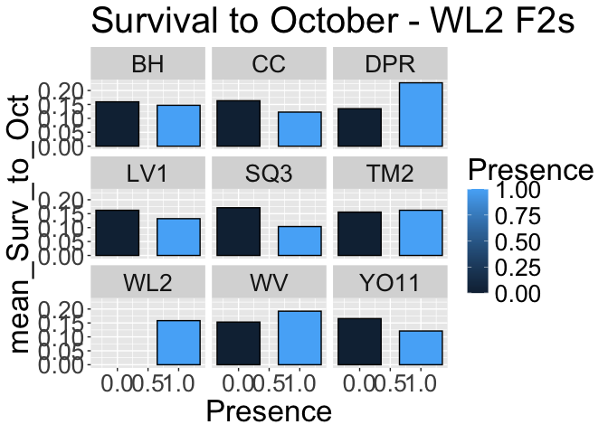

```r
wl2_surv_F2_binary_long_means %>%
  filter(WL2.cross=="TRUE") %>% #if want TM2 F1s just # this out
  ggplot(aes(x=Presence, y=mean_Surv_to_Oct, fill=Presence)) +
  geom_col(width = 0.7,position = position_dodge(0.75), colour="black") +
  #ylim(-0.05, 0.3) +
  labs(title="Survival to October - WL2 F2s") +
  #theme_classic() +
  theme(text=element_text(size=25)) +
  facet_wrap(~pop)
```

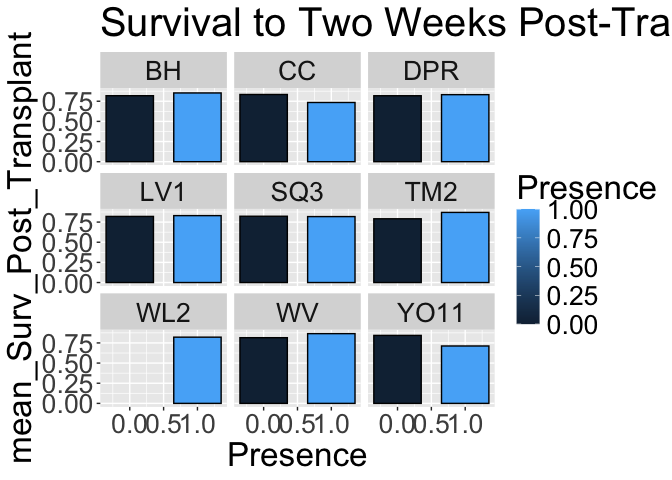

```r
ggsave("../output/WL2_Traits/F2s_SurvtoOct.png", width = 12, height = 6, units = "in")

wl2_surv_F2_binary_long_means %>%
  filter(WL2.cross=="TRUE") %>% #if want TM2 F1s just # this out
  ggplot(aes(x=Presence, y=mean_Surv_Post_Transplant, fill=Presence)) +
  geom_col(width = 0.7,position = position_dodge(0.75), colour="black") +
  labs(title="Survival to Two Weeks Post-Transplant  - WL2 F2s") +
  #theme_classic() +
  theme(text=element_text(size=25)) +
  facet_wrap(~pop)
```

```r
ggsave("../output/WL2_Traits/F2s_SurvPostTransplant.png", width = 12, height = 6, units = "in")
```

Just look at maternal and paternal pops

```r
unique(wl2_surv_F2_binary$parent.pop)
```

```
##  [1] "(WL2 x BH) x (WL2 x TM2)"   "(TM2 x WL2) x (SQ3 x WL2)"
##  [3] "(WL2 x TM2) x (CC x TM2)"   "(WL1 x TM2) x (WL2 x TM2)"
##  [5] "(TM2 x WL2) x (YO11 x WL2)" "(TM2 x WL2) x (TM2)"
##  [7] "(WL2 x DPR) x (TM2 x WL2)"  "(WL2 x BH) x (SQ3 x WL2)"
##  [9] "(WL1 x WL2) x (WL2 x CC)"   "(LV1 x WL2) x (YO11 x WL2)"
## [11] "(YO11 x WL2) x (WV x WL2)"  "(WV x WL2) x (WV)"
## [13] "(YO11 x WL2) x (SQ3 x WL2)" "(DPR x WL2) x (YO11 x WL2)"
## [15] "(WL2 x DPR) x (WL2)"        "(DPR x WL2) x (SQ3 x WL2)"
## [17] "(WL2) x (DPR x WL2)"        "(DPR) x (DPR x WL2)"
## [19] "(SQ3 x WL2) x (YO11 x WL2)" "(YO11 x WL2) x (DPR x WL2)"
## [21] "(SQ3 x WL2) x (WL2)"        "(YO11 x WL2) x (WL2)"
## [23] "(WL2 x CC) x (WL2 x TM2)"   "(LV1 x WL2) x (LV1 x WL2)"
## [25] "(WL1 x WL2) x (WL2 x TM2)"  "(WV) x (WV x WL2)"
## [27] "(SQ3 x WL2) x (TM2 x WL2)"  "(SQ3 x WL2) x (LV1 x WL2)"
## [29] "(TM2 x BH) x (TM2 x WL2)"   "(DPR x WL2) x (TM2 x WL2)"
## [31] "(DPR x WL2) x (WV x WL2)"   "(TM2 x WL2) x (WL2)"
## [33] "(WL2) x (WV x WL2)"         "(WL2 x DPR) x (DPR)"
## [35] "(TM2 x WL2) x (TM2 x BH)"   "(WL1 x WL2) x (BH x WL2)"
## [37] "(SQ3 x WL2) x (SQ3 x WL2)"  "(LV1 x WL2) x (WL2)"
## [39] "(DPR) x (WL2 x DPR)"        "(CC x TM2) x (WL2 x TM2)"
## [41] "(TM2 x WL2) x (TM2 x WL2)"  "(LV1 x WL2) x (WL2 x DPR)"
## [43] "(LV1 x WL2) x (SQ3 x WL2)"  "(LV1 x WL2) x (TM2 x WL2)"
## [45] "(SQ3 x WL2) x (DPR x WL2)"  "(WL2 x DPR) x (YO11 x WL2)"
## [47] "(YO11 x WL2) x (WL2 x TM2)" "(WL2) x (TM2 x WL2)"
## [49] "(TM2) x (TM2 x WL2)"        "(YO11 x WL2) x (TM2 x WL2)"
## [51] "(TM2 x WL2) x (WV x WL2)"   "(DPR x WL2) x (DPR x WL2)"
## [53] "(WL2 x CC) x (SQ3 x WL2)"   "(TM2 x WL2) x (LV1 x WL2)"
## [55] "(WL2 x TM2) x (WL2)"        "(WV x WL2) x (WL2 x DPR)"
## [57] "(TM2 x WL2) x (DPR x WL2)"
```

```r
unique(wl2_surv_F2_binary$maternal.pops)
```

```
##  [1] "WL2 x BH"   "TM2 x WL2"  "WL2 x TM2"  "WL1 x TM2"  "WL2 x DPR"
##  [6] "WL1 x WL2"  "LV1 x WL2"  "YO11 x WL2" "WV x WL2"   "DPR x WL2"
## [11] "WL2"        "DPR"        "SQ3 x WL2"  "WL2 x CC"   "WV"
## [16] "TM2 x BH"   "CC x TM2"   "TM2"
```

```r
xtabs(~Surv_to_Oct+maternal.pops, data=wl2_surv_F2_binary)
```

```
##            maternal.pops
## Surv_to_Oct CC x TM2 DPR DPR x WL2 LV1 x WL2 SQ3 x WL2 TM2 TM2 x BH TM2 x WL2
##           0        1  20        17        42        33   2        6        39
##           1        1   6         7         6         6   1        1        11
##            maternal.pops
## Surv_to_Oct WL1 x TM2 WL1 x WL2 WL2 WL2 x BH WL2 x CC WL2 x DPR WL2 x TM2 WV
##           0         6        28  21       17       15        16        14 14
##           1         0         3   3        2        2         4         3  2
##            maternal.pops
## Surv_to_Oct WV x WL2 YO11 x WL2
##           0       15         29
##           1        3          2
```

```r
unique(wl2_surv_F2_binary$paternal.pops)
```

```
##  [1] "WL2 x TM2"  "SQ3 x WL2"  "CC x TM2"   "YO11 x WL2" "TM2"
##  [6] "TM2 x WL2"  "WL2 x CC"   "WV x WL2"   "WV"         "WL2"
## [11] "DPR x WL2"  "LV1 x WL2"  "DPR"        "TM2 x BH"   "BH x WL2"
## [16] "WL2 x DPR"
```

```r
xtabs(~Surv_to_Oct+paternal.pops, data=wl2_surv_F2_binary)
```

```
##            paternal.pops
## Surv_to_Oct BH x WL2 CC x TM2 DPR DPR x WL2 LV1 x WL2 SQ3 x WL2 TM2 TM2 x BH
##           0        5       13   3        24         6        38   8        1
##           1        2        3   0         7         1         2   0        0
##            paternal.pops
## Surv_to_Oct TM2 x WL2 WL2 WL2 x CC WL2 x DPR WL2 x TM2 WV WV x WL2 YO11 x WL2
##           0        39  51       14        22        40 15       27         29
##           1         6  17        0         5         6  1        7          6
```

```r
wl2_surv_F2_binary_for_model <- wl2_surv_F2_binary %>%
  filter(paternal.pops!="TM2 x BH")
unique(wl2_surv_F2_binary_for_model$paternal.pops)
```

```
##  [1] "WL2 x TM2"  "SQ3 x WL2"  "CC x TM2"   "YO11 x WL2" "TM2"
##  [6] "TM2 x WL2"  "WL2 x CC"   "WV x WL2"   "WV"         "WL2"
## [11] "DPR x WL2"  "LV1 x WL2"  "DPR"        "BH x WL2"   "WL2 x DPR"
```

```r
unique(wl2_surv_F2_binary_for_model$maternal.pops)
```

```
##  [1] "WL2 x BH"   "TM2 x WL2"  "WL2 x TM2"  "WL1 x TM2"  "WL2 x DPR"
##  [6] "WL1 x WL2"  "LV1 x WL2"  "YO11 x WL2" "WV x WL2"   "DPR x WL2"
## [11] "WL2"        "DPR"        "SQ3 x WL2"  "WL2 x CC"   "WV"
## [16] "TM2 x BH"   "CC x TM2"   "TM2"
```

```r
xtabs(~Surv_to_Oct+paternal.pops, data=wl2_surv_F2_binary_for_model)
```

```
##            paternal.pops
## Surv_to_Oct BH x WL2 CC x TM2 DPR DPR x WL2 LV1 x WL2 SQ3 x WL2 TM2 TM2 x WL2
##           0        5       13   3        24         6        38   8        39
##           1        2        3   0         7         1         2   0         6
##            paternal.pops
## Surv_to_Oct WL2 WL2 x CC WL2 x DPR WL2 x TM2 WV WV x WL2 YO11 x WL2
##           0  51       14        22        40 15       27         29
##           1  17        0         5         6  1        7          6
```

Maternal Pops Plots

```r
wl2_surv_F2_binary_for_model_meansmat <- wl2_surv_F2_binary_for_model %>%
  group_by(WL2.cross, maternal.pops) %>%
  summarise(N_Surv = sum(!is.na(Surv_to_Oct)),
            mean_Surv_to_Oct = mean(Surv_to_Oct,na.rm=(TRUE)),
            mean_Surv_Post_Transplant = mean(Surv_Post_Transplant,na.rm=(TRUE)))
wl2_surv_F2_binary_for_model_meansmat
```

```
## # A tibble: 18 × 5
## # Groups:   WL2.cross [1]
##    WL2.cross maternal.pops N_Surv mean_Surv_to_Oct mean_Surv_Post_Transplant
##    <lgl>     <chr>          <int>            <dbl>                     <dbl>
##  1 TRUE      CC x TM2           2           0.5                        1
##  2 TRUE      DPR               26           0.231                      0.923
##  3 TRUE      DPR x WL2         24           0.292                      0.792
##  4 TRUE      LV1 x WL2         48           0.125                      0.833
##  5 TRUE      SQ3 x WL2         39           0.154                      0.769
##  6 TRUE      TM2                3           0.333                      1
##  7 TRUE      TM2 x BH           7           0.143                      0.857
##  8 TRUE      TM2 x WL2         49           0.224                      0.939
##  9 TRUE      WL1 x TM2          6           0                          0.833
## 10 TRUE      WL1 x WL2         31           0.0968                     0.645
## 11 TRUE      WL2               24           0.125                      0.792
## 12 TRUE      WL2 x BH          19           0.105                      0.842
## 13 TRUE      WL2 x CC          17           0.118                      0.824
## 14 TRUE      WL2 x DPR         20           0.2                        0.8
## 15 TRUE      WL2 x TM2         17           0.176                      0.882
## 16 TRUE      WV                16           0.125                      0.938
## 17 TRUE      WV x WL2          18           0.167                      0.889
## 18 TRUE      YO11 x WL2        31           0.0645                     0.677
```

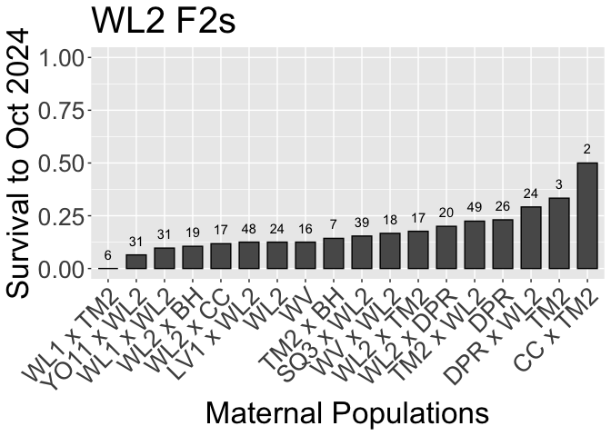

```r
wl2_surv_F2_binary_for_model_meansmat %>%
  ggplot(aes(x=fct_reorder(maternal.pops, mean_Surv_to_Oct), y=mean_Surv_to_Oct)) +
  geom_col(width = 0.7,position = position_dodge(0.75), colour="black") +
  labs(title="WL2 F2s", x="Maternal Populations", y="Survival to Oct 2024") +
  coord_cartesian(ylim = c(0, 1)) +
  geom_text(data = wl2_surv_F2_binary_for_model_meansmat, aes(label = N_Surv), vjust = -1) +
  #theme_classic() +
  theme(text=element_text(size=25), axis.text.x = element_text(angle = 45,  hjust = 1))
```

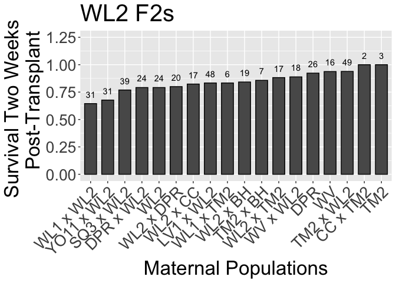

```r
ggsave("../output/WL2_Traits/F2s_SurvtoOct_MatPops.png", width = 12, height = 6, units = "in")

wl2_surv_F2_binary_for_model_meansmat %>%
  ggplot(aes(x=fct_reorder(maternal.pops, mean_Surv_Post_Transplant), y=mean_Surv_Post_Transplant)) +
  geom_col(width = 0.7,position = position_dodge(0.75), colour="black") +
  labs(title="WL2 F2s", x="Maternal Populations", y="Survival Two Weeks \n  Post-Transplant") +
  coord_cartesian(ylim = c(0, 1.25)) +
  scale_y_continuous(breaks = c(0.00, 0.25, 0.50, 0.75, 1.00, 1.25)) +
  geom_text(data = wl2_surv_F2_binary_for_model_meansmat, aes(label = N_Surv), vjust = -1) +
  #theme_classic() +
  theme(text=element_text(size=25), axis.text.x = element_text(angle = 45,  hjust = 1))
```

```r
ggsave("../output/WL2_Traits/F2s_SurvPostTransplant_MatPops.png", width = 12, height = 6, units = "in")
```

Paternal Pops Plots

```r
wl2_surv_F2_binary_for_model_meanspat <- wl2_surv_F2_binary_for_model %>%
  group_by(WL2.cross, paternal.pops) %>%
  summarise(N_Surv = sum(!is.na(Surv_to_Oct)),
            mean_Surv_to_Oct = mean(Surv_to_Oct,na.rm=(TRUE)),
            mean_Surv_Post_Transplant = mean(Surv_Post_Transplant,na.rm=(TRUE)))
wl2_surv_F2_binary_for_model_meanspat
```

```
## # A tibble: 15 × 5
## # Groups:   WL2.cross [1]
##    WL2.cross paternal.pops N_Surv mean_Surv_to_Oct mean_Surv_Post_Transplant
##    <lgl>     <chr>          <int>            <dbl>                     <dbl>
##  1 TRUE      BH x WL2           7           0.286                      1
##  2 TRUE      CC x TM2          16           0.188                      0.875
##  3 TRUE      DPR                3           0                          0.667
##  4 TRUE      DPR x WL2         31           0.226                      0.742
##  5 TRUE      LV1 x WL2          7           0.143                      0.571
##  6 TRUE      SQ3 x WL2         40           0.050                      0.875
##  7 TRUE      TM2                8           0                          0.75
##  8 TRUE      TM2 x WL2         45           0.133                      0.844
##  9 TRUE      WL2               68           0.25                       0.838
## 10 TRUE      WL2 x CC          14           0                          0.429
## 11 TRUE      WL2 x DPR         27           0.185                      1
## 12 TRUE      WL2 x TM2         46           0.130                      0.848
## 13 TRUE      WV                16           0.0625                     0.875
## 14 TRUE      WV x WL2          34           0.206                      0.853
## 15 TRUE      YO11 x WL2        35           0.171                      0.743
```

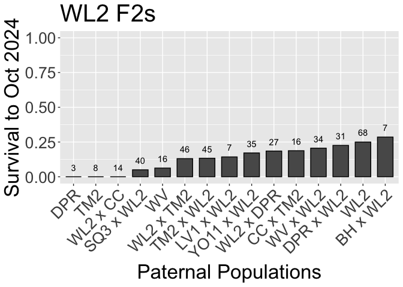

```r
wl2_surv_F2_binary_for_model_meanspat %>%
  ggplot(aes(x=fct_reorder(paternal.pops, mean_Surv_to_Oct), y=mean_Surv_to_Oct)) +
  geom_col(width = 0.7,position = position_dodge(0.75), colour="black") +
  labs(title="WL2 F2s", x="Paternal Populations", y="Survival to Oct 2024") +
  coord_cartesian(ylim = c(0, 1)) +
  geom_text(data = wl2_surv_F2_binary_for_model_meanspat, aes(label = N_Surv), vjust = -1) +
  #theme_classic() +
  theme(text=element_text(size=25), axis.text.x = element_text(angle = 45,  hjust = 1))
```

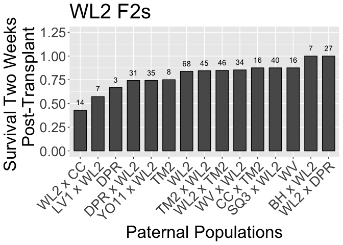

```r
ggsave("../output/WL2_Traits/F2s_SurvtoOct_PatPops.png", width = 12, height = 6, units = "in")

wl2_surv_F2_binary_for_model_meanspat %>%
  ggplot(aes(x=fct_reorder(paternal.pops, mean_Surv_Post_Transplant), y=mean_Surv_Post_Transplant)) +
  geom_col(width = 0.7,position = position_dodge(0.75), colour="black") +
  labs(title="WL2 F2s", x="Paternal Populations", y="Survival Two Weeks \n  Post-Transplant") +
  coord_cartesian(ylim = c(0, 1.25)) +
  scale_y_continuous(breaks = c(0.00, 0.25, 0.50, 0.75, 1.00, 1.25)) +
  geom_text(data = wl2_surv_F2_binary_for_model_meanspat, aes(label = N_Surv), vjust = -1) +
  #theme_classic() +
  theme(text=element_text(size=25), axis.text.x = element_text(angle = 45,  hjust = 1))
```

```r
ggsave("../output/WL2_Traits/F2s_SurvPostTransplant_PatPops.png", width = 12, height = 6, units = "in")
```

Maternal Pops Plots - BC2 prep

```r
wl2_surv_F2_binary_for_model_meansmat_BC2PREP <- wl2_surv_F2_binary_for_model %>%
  group_by(WL2.cross, maternal.pops) %>%
  filter(maternal.pops == "WL1 x WL2" | maternal.pops == "WL2 x BH" | maternal.pops == "WL2" |
           maternal.pops == "WV" | maternal.pops == "WV x WL2" | maternal.pops == "WL2 x TM2" |
           maternal.pops == "WL2 x DPR" | maternal.pops == "TM2 x WL2" | maternal.pops == "DPR" |
           maternal.pops == "DPR x WL2" | maternal.pops == "TM2") %>% #FOR BC2 PREP
  summarise(N_Surv = sum(!is.na(Surv_to_Oct)),
            mean_Surv_to_Oct = mean(Surv_to_Oct,na.rm=(TRUE)),
            mean_Surv_Post_Transplant = mean(Surv_Post_Transplant,na.rm=(TRUE)))
wl2_surv_F2_binary_for_model_meansmat_BC2PREP
```

```
## # A tibble: 11 × 5
## # Groups:   WL2.cross [1]
##    WL2.cross maternal.pops N_Surv mean_Surv_to_Oct mean_Surv_Post_Transplant
##    <lgl>     <chr>          <int>            <dbl>                     <dbl>
##  1 TRUE      DPR               26           0.231                      0.923
##  2 TRUE      DPR x WL2         24           0.292                      0.792
##  3 TRUE      TM2                3           0.333                      1
##  4 TRUE      TM2 x WL2         49           0.224                      0.939
##  5 TRUE      WL1 x WL2         31           0.0968                     0.645
##  6 TRUE      WL2               24           0.125                      0.792
##  7 TRUE      WL2 x BH          19           0.105                      0.842
##  8 TRUE      WL2 x DPR         20           0.2                        0.8
##  9 TRUE      WL2 x TM2         17           0.176                      0.882
## 10 TRUE      WV                16           0.125                      0.938
## 11 TRUE      WV x WL2          18           0.167                      0.889
```

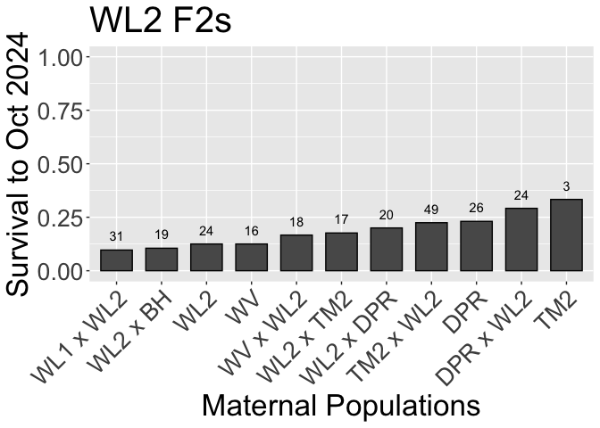

```r
wl2_surv_F2_binary_for_model_meansmat_BC2PREP %>%
  ggplot(aes(x=fct_reorder(maternal.pops, mean_Surv_to_Oct), y=mean_Surv_to_Oct)) +
  geom_col(width = 0.7,position = position_dodge(0.75), colour="black") +
  labs(title="WL2 F2s", x="Maternal Populations", y="Survival to Oct 2024") +
  coord_cartesian(ylim = c(0, 1)) +
  geom_text(data = wl2_surv_F2_binary_for_model_meansmat_BC2PREP, aes(label = N_Surv), vjust = -1) +
  #theme_classic() +
  theme(text=element_text(size=25), axis.text.x = element_text(angle = 45,  hjust = 1))
```

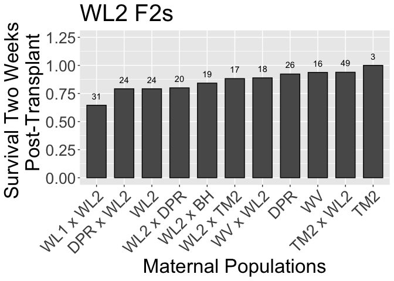

```r
ggsave("../output/WL2_Traits/F2s_SurvtoOct_MatPops_BC2PREP.png", width = 8, height = 6, units = "in")

wl2_surv_F2_binary_for_model_meansmat_BC2PREP %>%
  ggplot(aes(x=fct_reorder(maternal.pops, mean_Surv_Post_Transplant), y=mean_Surv_Post_Transplant)) +
  geom_col(width = 0.7,position = position_dodge(0.75), colour="black") +
  labs(title="WL2 F2s", x="Maternal Populations", y="Survival Two Weeks \n  Post-Transplant") +
  coord_cartesian(ylim = c(0, 1.25)) +
  scale_y_continuous(breaks = c(0.00, 0.25, 0.50, 0.75, 1.00, 1.25)) +
  geom_text(data = wl2_surv_F2_binary_for_model_meansmat_BC2PREP, aes(label = N_Surv), vjust = -1) +
  #theme_classic() +
  theme(text=element_text(size=25), axis.text.x = element_text(angle = 45,  hjust = 1))
```

```r
ggsave("../output/WL2_Traits/F2s_SurvPostTransplant_MatPops_BC2PREP.png", width = 8, height = 6, units = "in")
```

Paternal Pops Plots - BC2 prep

```r
wl2_surv_F2_binary_for_model_meanspat_BC2PREP <- wl2_surv_F2_binary_for_model %>%
  group_by(WL2.cross, paternal.pops) %>%
  filter(paternal.pops == "BH x WL2" | paternal.pops == "WL2" |
           paternal.pops == "WV" | paternal.pops == "WV x WL2" | paternal.pops == "WL2 x TM2" |
           paternal.pops == "WL2 x DPR" | paternal.pops == "TM2 x WL2" | paternal.pops == "DPR" |
           paternal.pops == "DPR x WL2" | paternal.pops == "TM2") %>% #FOR BC2 PREP
  summarise(N_Surv = sum(!is.na(Surv_to_Oct)),
            mean_Surv_to_Oct = mean(Surv_to_Oct,na.rm=(TRUE)),
            mean_Surv_Post_Transplant = mean(Surv_Post_Transplant,na.rm=(TRUE)))
wl2_surv_F2_binary_for_model_meanspat_BC2PREP
```

```
## # A tibble: 10 × 5
## # Groups:   WL2.cross [1]
##    WL2.cross paternal.pops N_Surv mean_Surv_to_Oct mean_Surv_Post_Transplant
##    <lgl>     <chr>          <int>            <dbl>                     <dbl>
##  1 TRUE      BH x WL2           7           0.286                      1
##  2 TRUE      DPR                3           0                          0.667
##  3 TRUE      DPR x WL2         31           0.226                      0.742
##  4 TRUE      TM2                8           0                          0.75
##  5 TRUE      TM2 x WL2         45           0.133                      0.844
##  6 TRUE      WL2               68           0.25                       0.838
##  7 TRUE      WL2 x DPR         27           0.185                      1
##  8 TRUE      WL2 x TM2         46           0.130                      0.848
##  9 TRUE      WV                16           0.0625                     0.875
## 10 TRUE      WV x WL2          34           0.206                      0.853
```

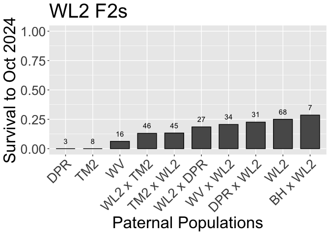

```r
wl2_surv_F2_binary_for_model_meanspat_BC2PREP %>%
  ggplot(aes(x=fct_reorder(paternal.pops, mean_Surv_to_Oct), y=mean_Surv_to_Oct)) +
  geom_col(width = 0.7,position = position_dodge(0.75), colour="black") +
  labs(title="WL2 F2s", x="Paternal Populations", y="Survival to Oct 2024") +
  coord_cartesian(ylim = c(0, 1)) +
  geom_text(data = wl2_surv_F2_binary_for_model_meanspat_BC2PREP, aes(label = N_Surv), vjust = -1) +
  #theme_classic() +
  theme(text=element_text(size=25), axis.text.x = element_text(angle = 45,  hjust = 1))
```

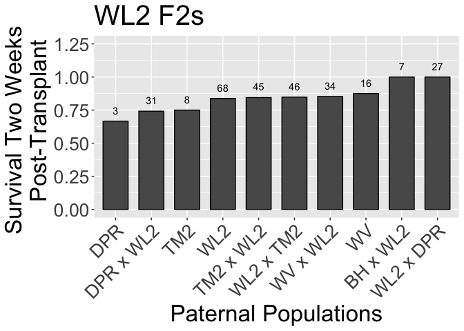

```r
ggsave("../output/WL2_Traits/F2s_SurvtoOct_PatPops_BC2PREP.png", width = 12, height = 6, units = "in")

wl2_surv_F2_binary_for_model_meanspat_BC2PREP %>%
  ggplot(aes(x=fct_reorder(paternal.pops, mean_Surv_Post_Transplant), y=mean_Surv_Post_Transplant)) +
  geom_col(width = 0.7,position = position_dodge(0.75), colour="black") +
  labs(title="WL2 F2s", x="Paternal Populations", y="Survival Two Weeks \n  Post-Transplant") +
  coord_cartesian(ylim = c(0, 1.25)) +
  scale_y_continuous(breaks = c(0.00, 0.25, 0.50, 0.75, 1.00, 1.25)) +
  geom_text(data = wl2_surv_F2_binary_for_model_meanspat_BC2PREP, aes(label = N_Surv), vjust = -1) +
  #theme_classic() +
  theme(text=element_text(size=25), axis.text.x = element_text(angle = 45,  hjust = 1))
```

```r
ggsave("../output/WL2_Traits/F2s_SurvPostTransplant_PatPops_BC2PREP.png", width = 12, height = 6, units = "in")
```

### Bayesian random - maternal and paternal pops

#### Surv to Oct

```r
surv_parent_binary_bf2 <- brmsformula(Surv_to_Oct ~ (1|maternal.pops)+(1|paternal.pops))

get_prior(surv_parent_binary_bf2, family = "bernoulli", data = wl2_surv_F2_binary_for_model)
```

```
##                 prior     class      coef         group resp dpar nlpar lb ub
##  student_t(3, 0, 2.5) Intercept
##  student_t(3, 0, 2.5)        sd                                          0
##  student_t(3, 0, 2.5)        sd           maternal.pops                  0
##  student_t(3, 0, 2.5)        sd Intercept maternal.pops                  0
##  student_t(3, 0, 2.5)        sd           paternal.pops                  0
##  student_t(3, 0, 2.5)        sd Intercept paternal.pops                  0
##        source
##       default
##       default
##  (vectorized)
##  (vectorized)
##  (vectorized)
##  (vectorized)
```

```r
surv_parent_binary_m2 <- brm(surv_parent_binary_bf2,
                             family = "bernoulli",
                             data = wl2_surv_F2_binary_for_model,
                             cores=4,
                             iter = 4000, #increased iterations b/c complex model
                             control = list(adapt_delta = 0.9),
                             sample_prior = "yes", # needed for hypothesis testing
                             prior=prior1) #increased adapt_delta to help with divergent transitions
```

```
## Trying to compile a simple C file
```

[output not shown]

```r
prior_summary(surv_parent_binary_m2)
```

```
##         prior     class      coef         group resp dpar nlpar lb ub
##  normal(0, 5) Intercept
##  normal(0, 5)        sd                                          0
##  normal(0, 5)        sd           maternal.pops                  0
##  normal(0, 5)        sd Intercept maternal.pops                  0
##  normal(0, 5)        sd           paternal.pops                  0
##  normal(0, 5)        sd Intercept paternal.pops                  0
##        source
##          user
##          user
##  (vectorized)
##  (vectorized)
##  (vectorized)
##  (vectorized)
```

```r
summary(surv_parent_binary_m2)
```

```
##  Family: bernoulli
##   Links: mu = logit
## Formula: Surv_to_Oct ~ (1 | maternal.pops) + (1 | paternal.pops)
##    Data: wl2_surv_F2_binary_for_model (Number of observations: 397)
##   Draws: 4 chains, each with iter = 4000; warmup = 2000; thin = 1;
##          total post-warmup draws = 8000
##
## Multilevel Hyperparameters:
## ~maternal.pops (Number of levels: 18)
##               Estimate Est.Error l-95% CI u-95% CI Rhat Bulk_ESS Tail_ESS
## sd(Intercept)     0.29      0.21     0.01     0.77 1.00     2860     4176
##
## ~paternal.pops (Number of levels: 15)
##               Estimate Est.Error l-95% CI u-95% CI Rhat Bulk_ESS Tail_ESS
## sd(Intercept)     0.47      0.29     0.04     1.17 1.00     1876     2995
##
## Regression Coefficients:
##           Estimate Est.Error l-95% CI u-95% CI Rhat Bulk_ESS Tail_ESS
## Intercept    -1.81      0.25    -2.37    -1.37 1.00     3902     2963
##
## Draws were sampled using sampling(NUTS). For each parameter, Bulk_ESS
## and Tail_ESS are effective sample size measures, and Rhat is the potential
## scale reduction factor on split chains (at convergence, Rhat = 1).
```

```r
#Rhat <1.05 (good!)
#ESS > 1000 (good!)
```

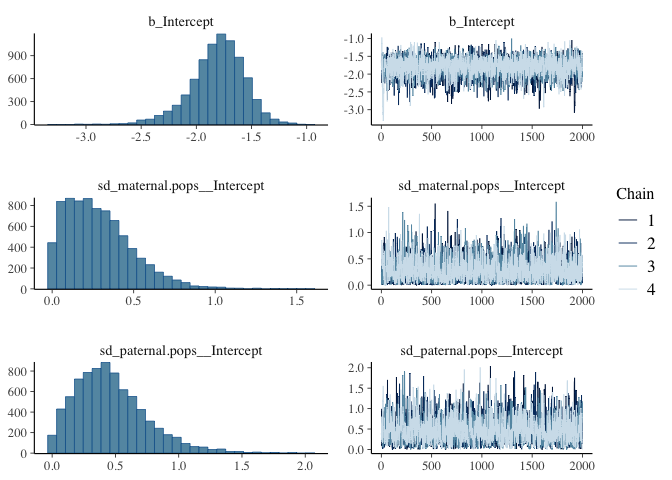

```r
plot(surv_parent_binary_m2,  nvariables = 3, ask=FALSE) #plots look better
```

```
## Using 10 posterior draws for ppc type 'dens_overlay' by default.
```

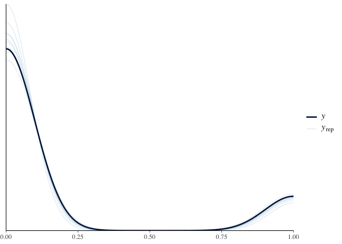

```r
#pairs(surv_parent_binary_m2)

pp_check(surv_parent_binary_m2)  # posterior predictive checks
```

```r
#some draws differ from posterior distribution
```

To calcualte the stats we need to extract the posterior samples, and add the Intercept to each pop random effect, and then compute the stats.

```r
intercept <- as_draws_df(surv_parent_binary_m2, variable = "b_Intercept") %>% as_tibble() %>% select(starts_with("b"))

r_pops_raw <- as_draws_df(surv_parent_binary_m2, variable = "*r_", regex = TRUE) %>% as_tibble() %>% select(starts_with("r"))

r_pops <- r_pops_raw %>% mutate(across(everything(), ~ .x + intercept$b_Intercept))
```

##### Hypothesis Testing

```r
hypothesis(surv_parent_binary_m2,
           class = NULL,
           hypothesis = "r_maternal.pops[CC.x.TM2,Intercept] > 0",
           scope = "standard")
```

```
## Hypothesis Tests for class :
##                 Hypothesis Estimate Est.Error CI.Lower CI.Upper Evid.Ratio
## 1 (r_maternal.pops[... > 0     0.08      0.36    -0.43     0.72       1.38
##   Post.Prob Star
## 1      0.58
## ---
## 'CI': 90%-CI for one-sided and 95%-CI for two-sided hypotheses.
## '*': For one-sided hypotheses, the posterior probability exceeds 95%;
## for two-sided hypotheses, the value tested against lies outside the 95%-CI.
## Posterior probabilities of point hypotheses assume equal prior probabilities.
```

```r
hypothesis(surv_parent_binary_m2,
           class = NULL,
           hypothesis = "r_maternal.pops[DPR.x.WL2,Intercept] > 0",
           scope = "standard")
```

```
## Hypothesis Tests for class :
##                 Hypothesis Estimate Est.Error CI.Lower CI.Upper Evid.Ratio
## 1 (r_maternal.pops[... > 0     0.23      0.32    -0.15     0.87       3.09
##   Post.Prob Star
## 1      0.76
## ---
## 'CI': 90%-CI for one-sided and 95%-CI for two-sided hypotheses.
## '*': For one-sided hypotheses, the posterior probability exceeds 95%;
## for two-sided hypotheses, the value tested against lies outside the 95%-CI.
## Posterior probabilities of point hypotheses assume equal prior probabilities.
```

```r
hypothesis(surv_parent_binary_m2,
           class = NULL,
           hypothesis = "r_maternal.pops[TM2,Intercept] > 0",
           scope = "standard")
```

```
## Hypothesis Tests for class :
##                 Hypothesis Estimate Est.Error CI.Lower CI.Upper Evid.Ratio
## 1 (r_maternal.pops[... > 0     0.07      0.33    -0.41     0.68        1.3
##   Post.Prob Star
## 1      0.56
## ---
## 'CI': 90%-CI for one-sided and 95%-CI for two-sided hypotheses.
## '*': For one-sided hypotheses, the posterior probability exceeds 95%;
## for two-sided hypotheses, the value tested against lies outside the 95%-CI.
## Posterior probabilities of point hypotheses assume equal prior probabilities.
```

This shows that the posterior probability that CC x TM2 (mom) increases survivability is 0.58 Same prob for DPR x WL2 (MOM) is 0.76 Same prob for TM2 (mom) = 0.57

```r
hypothesis(surv_parent_binary_m2,
           class = NULL,
           hypothesis = "r_paternal.pops[BH.x.WL2,Intercept] > 0",
           scope = "standard")
```

```
## Hypothesis Tests for class :
##                 Hypothesis Estimate Est.Error CI.Lower CI.Upper Evid.Ratio
## 1 (r_paternal.pops[... > 0      0.2      0.49    -0.48     1.08       1.89
##   Post.Prob Star
## 1      0.65
## ---
## 'CI': 90%-CI for one-sided and 95%-CI for two-sided hypotheses.
## '*': For one-sided hypotheses, the posterior probability exceeds 95%;
## for two-sided hypotheses, the value tested against lies outside the 95%-CI.
## Posterior probabilities of point hypotheses assume equal prior probabilities.
```

```r
hypothesis(surv_parent_binary_m2,
           class = NULL,
           hypothesis = "r_paternal.pops[DPR.x.WL2,Intercept] > 0",
           scope = "standard")
```

```
## Hypothesis Tests for class :
##                 Hypothesis Estimate Est.Error CI.Lower CI.Upper Evid.Ratio
## 1 (r_paternal.pops[... > 0     0.27       0.4    -0.26     1.03       3.07
##   Post.Prob Star
## 1      0.75
## ---
## 'CI': 90%-CI for one-sided and 95%-CI for two-sided hypotheses.
## '*': For one-sided hypotheses, the posterior probability exceeds 95%;
## for two-sided hypotheses, the value tested against lies outside the 95%-CI.
## Posterior probabilities of point hypotheses assume equal prior probabilities.
```

```r
hypothesis(surv_parent_binary_m2,
           class = NULL,
           hypothesis = "r_paternal.pops[WL2,Intercept] > 0",
           scope = "standard")
```

```
## Hypothesis Tests for class :
##                 Hypothesis Estimate Est.Error CI.Lower CI.Upper Evid.Ratio
## 1 (r_paternal.pops[... > 0     0.45      0.38    -0.04     1.13       9.74
##   Post.Prob Star
## 1      0.91
## ---
## 'CI': 90%-CI for one-sided and 95%-CI for two-sided hypotheses.
## '*': For one-sided hypotheses, the posterior probability exceeds 95%;
## for two-sided hypotheses, the value tested against lies outside the 95%-CI.
## Posterior probabilities of point hypotheses assume equal prior probabilities.
```

test whether DPR x WL2 increases survival probability *more* than other pops

```r
hypothesis(surv_parent_binary_m2,
           class = NULL,
           hypothesis = "r_maternal.pops[DPR.x.WL2,Intercept] > r_maternal.pops[WL2,Intercept]",
           scope = "standard")
```

```
## Hypothesis Tests for class :
##                 Hypothesis Estimate Est.Error CI.Lower CI.Upper Evid.Ratio
## 1 (r_maternal.pops[... > 0     0.31      0.46    -0.22     1.24       2.95
##   Post.Prob Star
## 1      0.75
## ---
## 'CI': 90%-CI for one-sided and 95%-CI for two-sided hypotheses.
## '*': For one-sided hypotheses, the posterior probability exceeds 95%;
## for two-sided hypotheses, the value tested against lies outside the 95%-CI.
## Posterior probabilities of point hypotheses assume equal prior probabilities.
```

```r
hypothesis(surv_parent_binary_m2,
           class = NULL,
           hypothesis = "r_maternal.pops[DPR.x.WL2,Intercept] > r_maternal.pops[DPR,Intercept]",
           scope = "standard")
```

```
## Hypothesis Tests for class :
##                 Hypothesis Estimate Est.Error CI.Lower CI.Upper Evid.Ratio
## 1 (r_maternal.pops[... > 0     0.13      0.39    -0.41     0.87       1.63
##   Post.Prob Star
## 1      0.62
## ---
## 'CI': 90%-CI for one-sided and 95%-CI for two-sided hypotheses.
## '*': For one-sided hypotheses, the posterior probability exceeds 95%;
## for two-sided hypotheses, the value tested against lies outside the 95%-CI.
## Posterior probabilities of point hypotheses assume equal prior probabilities.
```

This shows that the posterior probability that DPR x WL2 is better than WL2 is 0.75 (MOMS) posterior probability that DPR x WL2 is better than DPR is 0.61 (MOMS)

test whether DPR x WL2 increases survival probability *more* than other pops

```r
hypothesis(surv_parent_binary_m2,
           class = NULL,
           hypothesis = "r_paternal.pops[DPR.x.WL2,Intercept] > r_paternal.pops[WV,Intercept]",
           scope = "standard")
```

```
## Hypothesis Tests for class :
##                 Hypothesis Estimate Est.Error CI.Lower CI.Upper Evid.Ratio
## 1 (r_paternal.pops[... > 0     0.51      0.66     -0.3     1.75       3.89
##   Post.Prob Star
## 1       0.8
## ---
## 'CI': 90%-CI for one-sided and 95%-CI for two-sided hypotheses.
## '*': For one-sided hypotheses, the posterior probability exceeds 95%;
## for two-sided hypotheses, the value tested against lies outside the 95%-CI.
## Posterior probabilities of point hypotheses assume equal prior probabilities.
```

```r
hypothesis(surv_parent_binary_m2,
           class = NULL,
           hypothesis = "r_paternal.pops[WL2,Intercept] > r_paternal.pops[DPR.x.WL2,Intercept]",
           scope = "standard")
```

```
## Hypothesis Tests for class :
##                 Hypothesis Estimate Est.Error CI.Lower CI.Upper Evid.Ratio
## 1 (r_paternal.pops[... > 0     0.18      0.42    -0.49      0.9       2.03
##   Post.Prob Star
## 1      0.67
## ---
## 'CI': 90%-CI for one-sided and 95%-CI for two-sided hypotheses.
## '*': For one-sided hypotheses, the posterior probability exceeds 95%;
## for two-sided hypotheses, the value tested against lies outside the 95%-CI.
## Posterior probabilities of point hypotheses assume equal prior probabilities.
```

posterior probability that DPR x WL2 is better than WV is 0.8 (DADS) posterior probability that WL2 is better than DPR x WL2 is 0.67 (DADS)

Maternal vs. paternal

```r
hypothesis(surv_parent_binary_m2,
           class = NULL,
           hypothesis = "r_maternal.pops[DPR,Intercept] > r_paternal.pops[DPR,Intercept]",
           scope = "standard")
```

```
## Hypothesis Tests for class :
##                 Hypothesis Estimate Est.Error CI.Lower CI.Upper Evid.Ratio
## 1 (r_maternal.pops[... > 0     0.21      0.58    -0.65     1.24       1.81
##   Post.Prob Star
## 1      0.64
## ---
## 'CI': 90%-CI for one-sided and 95%-CI for two-sided hypotheses.
## '*': For one-sided hypotheses, the posterior probability exceeds 95%;
## for two-sided hypotheses, the value tested against lies outside the 95%-CI.
## Posterior probabilities of point hypotheses assume equal prior probabilities.
```

```r
hypothesis(surv_parent_binary_m2,
           class = NULL,
           hypothesis = "r_maternal.pops[TM2,Intercept] > r_paternal.pops[TM2,Intercept]",
           scope = "standard")
```

```
## Hypothesis Tests for class :
##                 Hypothesis Estimate Est.Error CI.Lower CI.Upper Evid.Ratio
## 1 (r_maternal.pops[... > 0     0.34      0.64     -0.5     1.53       2.37
##   Post.Prob Star
## 1       0.7
## ---
## 'CI': 90%-CI for one-sided and 95%-CI for two-sided hypotheses.
## '*': For one-sided hypotheses, the posterior probability exceeds 95%;
## for two-sided hypotheses, the value tested against lies outside the 95%-CI.
## Posterior probabilities of point hypotheses assume equal prior probabilities.
```

```r
hypothesis(surv_parent_binary_m2,
           class = NULL,
           hypothesis = "r_maternal.pops[WV,Intercept] > r_paternal.pops[WV,Intercept]",
           scope = "standard")
```

```
## Hypothesis Tests for class :
##                 Hypothesis Estimate Est.Error CI.Lower CI.Upper Evid.Ratio
## 1 (r_maternal.pops[... > 0     0.17      0.54    -0.61     1.12       1.61
##   Post.Prob Star
## 1      0.62
## ---
## 'CI': 90%-CI for one-sided and 95%-CI for two-sided hypotheses.
## '*': For one-sided hypotheses, the posterior probability exceeds 95%;
## for two-sided hypotheses, the value tested against lies outside the 95%-CI.
## Posterior probabilities of point hypotheses assume equal prior probabilities.
```

```r
hypothesis(surv_parent_binary_m2,
           class = NULL,
           hypothesis = "r_paternal.pops[WL2,Intercept] > r_maternal.pops[WL2,Intercept]",
           scope = "standard")
```

```
## Hypothesis Tests for class :
##                 Hypothesis Estimate Est.Error CI.Lower CI.Upper Evid.Ratio
## 1 (r_paternal.pops[... > 0     0.54       0.5    -0.14     1.42       7.54
##   Post.Prob Star
## 1      0.88
## ---
## 'CI': 90%-CI for one-sided and 95%-CI for two-sided hypotheses.
## '*': For one-sided hypotheses, the posterior probability exceeds 95%;
## for two-sided hypotheses, the value tested against lies outside the 95%-CI.
## Posterior probabilities of point hypotheses assume equal prior probabilities.
```

##### Hand calculated model output

```r
posterior::summarize_draws(r_pops) %>%
  mutate(across(mean:q95, inv_logit_scaled))
```

```
## # A tibble: 33 × 10
##    variable         mean median    sd   mad     q5   q95  rhat ess_bulk ess_tail
##    <chr>           <dbl>  <dbl> <dbl> <dbl>  <dbl> <dbl> <dbl>    <dbl>    <dbl>
##  1 r_maternal.pop… 0.151  0.150 0.606 0.582 0.0822 0.264  1.00    5928.    5220.
##  2 r_maternal.pop… 0.152  0.153 0.587 0.574 0.0917 0.240  1.00    5535.    4378.
##  3 r_maternal.pop… 0.170  0.166 0.591 0.581 0.106  0.282  1.00    4872.    4477.
##  4 r_maternal.pop… 0.128  0.133 0.586 0.577 0.0717 0.190  1.00    4499.    4031.
##  5 r_maternal.pop… 0.136  0.140 0.584 0.574 0.0783 0.204  1.00    4740.    3785.
##  6 r_maternal.pop… 0.149  0.149 0.599 0.580 0.0843 0.252  1.00    5422.    4479.
##  7 r_maternal.pop… 0.141  0.144 0.601 0.582 0.0755 0.234  1.00    6503.    4804.
##  8 r_maternal.pop… 0.164  0.162 0.579 0.572 0.105  0.253  1.00    4903.    5379.
##  9 r_maternal.pop… 0.130  0.137 0.605 0.583 0.0653 0.208  1.00    5886.    4000.
## 10 r_maternal.pop… 0.130  0.135 0.590 0.578 0.0711 0.199  1.00    6301.    5021.
## # ℹ 23 more rows
```

```r
#estimates seem to be a little off...
```

##### Tidybayes tables

```r
#tibble(maternal.pops = "CC.x.TM2") %>%
 # add_epred_draws(surv_parent_binary_m2) %>%
  #median_qi(.epred)
#CAN'T USE THIS CODE FOR F2s because it wants info about maternal and paternal pops (pairs)
```

##### Tidy Plot

NEED TO FIGURE OUT HOW TO MAKE THIS PLOT WHEN TO RANDOM EFFECTS IN MODEL

```r
wl2_surv_F2_binary_for_model %>%
  data_grid(maternal.pops, paternal.pops) %>%
  add_epred_draws(surv_parent_binary_m2) %>%
  ggplot(aes(y = maternal.pops, x = .epred)) +
  stat_slab() +
  theme_classic() +
  labs(x="Posterior Survival Predictions", y="Maternal Parent", title="F1 Survival to October") +
  theme(text=element_text(size=25))
ggsave("../output/WL2_Traits/F2s_SurvtoOct_PostProb.png", width = 8, height = 6, units = "in")
```

#### Surv Post Transplant

```r
surv_parent_binary_bf5 <- brmsformula(Surv_Post_Transplant ~ (1|maternal.pops)+(1|paternal.pops))

get_prior(surv_parent_binary_bf5, family = "bernoulli", data = wl2_surv_F2_binary_for_model)
```

```
##                 prior     class      coef         group resp dpar nlpar lb ub
##  student_t(3, 0, 2.5) Intercept
##  student_t(3, 0, 2.5)        sd                                          0
##  student_t(3, 0, 2.5)        sd           maternal.pops                  0
##  student_t(3, 0, 2.5)        sd Intercept maternal.pops                  0
##  student_t(3, 0, 2.5)        sd           paternal.pops                  0
##  student_t(3, 0, 2.5)        sd Intercept paternal.pops                  0
##        source
##       default
##       default
##  (vectorized)
##  (vectorized)
##  (vectorized)
##  (vectorized)
```

```r
#excluded plants with only 3 parents
```

```r
surv_parent_binary_m5 <- brm(surv_parent_binary_bf5,
                             family = "bernoulli",
                             data = wl2_surv_F2_binary_for_model,
                             cores=4,
                             iter = 5000, #increased iterations b/c complex model
                             control = list(adapt_delta = 0.9),
                             sample_prior = "yes", # needed for hypothesis testing
                             prior=prior1) #increased adapt_delta to help with divergent transitions
```

```
## Trying to compile a simple C file
```

[output not shown]

```r
prior_summary(surv_parent_binary_m5)
```

```
##         prior     class      coef         group resp dpar nlpar lb ub
##  normal(0, 5) Intercept
##  normal(0, 5)        sd                                          0
##  normal(0, 5)        sd           maternal.pops                  0
##  normal(0, 5)        sd Intercept maternal.pops                  0
##  normal(0, 5)        sd           paternal.pops                  0
##  normal(0, 5)        sd Intercept paternal.pops                  0
##        source
##          user
##          user
##  (vectorized)
##  (vectorized)
##  (vectorized)
##  (vectorized)
```

```r
summary(surv_parent_binary_m5)
```

```
##  Family: bernoulli
##   Links: mu = logit
## Formula: Surv_Post_Transplant ~ (1 | maternal.pops) + (1 | paternal.pops)
##    Data: wl2_surv_F2_binary_for_model (Number of observations: 397)
##   Draws: 4 chains, each with iter = 5000; warmup = 2500; thin = 1;
##          total post-warmup draws = 10000
##
## Multilevel Hyperparameters:
## ~maternal.pops (Number of levels: 18)
##               Estimate Est.Error l-95% CI u-95% CI Rhat Bulk_ESS Tail_ESS
## sd(Intercept)     0.44      0.24     0.04     0.96 1.00     3150     3455
##
## ~paternal.pops (Number of levels: 15)
##               Estimate Est.Error l-95% CI u-95% CI Rhat Bulk_ESS Tail_ESS
## sd(Intercept)     0.66      0.35     0.07     1.47 1.00     2036     2419
##
## Regression Coefficients:
##           Estimate Est.Error l-95% CI u-95% CI Rhat Bulk_ESS Tail_ESS
## Intercept     1.62      0.29     1.06     2.21 1.00     5702     4760
##
## Draws were sampled using sampling(NUTS). For each parameter, Bulk_ESS
## and Tail_ESS are effective sample size measures, and Rhat is the potential
## scale reduction factor on split chains (at convergence, Rhat = 1).
```

```r
#Rhat <1.05 (good!)
#ESS > 1000 (good!)
```

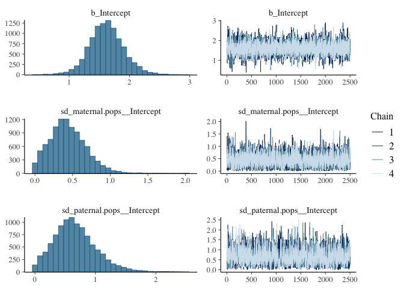

```r
plot(surv_parent_binary_m5,  nvariables = 3, ask=FALSE) #plots look better
```

```
## Using 10 posterior draws for ppc type 'dens_overlay' by default.
```

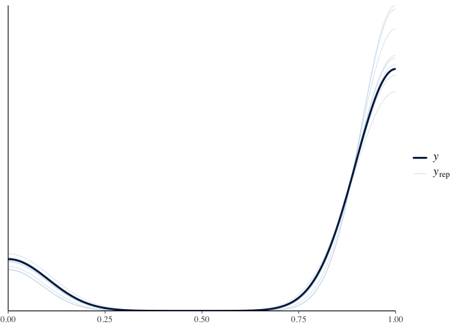

```r
#pairs(surv_parent_binary_m5)

pp_check(surv_parent_binary_m5)  # posterior predictive checks
```

```r
#some draws differ from posterior distribution
```

To calculate the stats we need to extract the posterior samples, and add the Intercept to each pop random effect, and then compute the stats.

```r
intercept <- as_draws_df(surv_parent_binary_m5, variable = "b_Intercept") %>% as_tibble() %>% select(starts_with("b"))

r_pops_raw <- as_draws_df(surv_parent_binary_m5, variable = "*r_", regex = TRUE) %>% as_tibble() %>% select(starts_with("r"))

r_pops <- r_pops_raw %>% mutate(across(everything(), ~ .x + intercept$b_Intercept))
```

##### Hypothesis Testing

```r
hypothesis(surv_parent_binary_m5,
           class = NULL,
           hypothesis = "r_maternal.pops[TM2.x.WL2,Intercept] > 0",
           scope = "standard")
```

```
## Hypothesis Tests for class :
##                 Hypothesis Estimate Est.Error CI.Lower CI.Upper Evid.Ratio
## 1 (r_maternal.pops[... > 0     0.49      0.43    -0.06      1.3       8.93
##   Post.Prob Star
## 1       0.9
## ---
## 'CI': 90%-CI for one-sided and 95%-CI for two-sided hypotheses.
## '*': For one-sided hypotheses, the posterior probability exceeds 95%;
## for two-sided hypotheses, the value tested against lies outside the 95%-CI.
## Posterior probabilities of point hypotheses assume equal prior probabilities.
```

```r
hypothesis(surv_parent_binary_m5,
           class = NULL,
           hypothesis = "r_maternal.pops[CC.x.TM2,Intercept] > 0",
           scope = "standard")
```

```
## Hypothesis Tests for class :
##                 Hypothesis Estimate Est.Error CI.Lower CI.Upper Evid.Ratio
## 1 (r_maternal.pops[... > 0     0.06      0.48     -0.7     0.88       1.21
##   Post.Prob Star
## 1      0.55
## ---
## 'CI': 90%-CI for one-sided and 95%-CI for two-sided hypotheses.
## '*': For one-sided hypotheses, the posterior probability exceeds 95%;
## for two-sided hypotheses, the value tested against lies outside the 95%-CI.
## Posterior probabilities of point hypotheses assume equal prior probabilities.
```

```r
hypothesis(surv_parent_binary_m5,
           class = NULL,
           hypothesis = "r_maternal.pops[TM2,Intercept] > 0",
           scope = "standard")
```

```
## Hypothesis Tests for class :
##                 Hypothesis Estimate Est.Error CI.Lower CI.Upper Evid.Ratio
## 1 (r_maternal.pops[... > 0      0.1      0.49    -0.63     0.96       1.37
##   Post.Prob Star
## 1      0.58
## ---
## 'CI': 90%-CI for one-sided and 95%-CI for two-sided hypotheses.
## '*': For one-sided hypotheses, the posterior probability exceeds 95%;
## for two-sided hypotheses, the value tested against lies outside the 95%-CI.
## Posterior probabilities of point hypotheses assume equal prior probabilities.
```

```r
hypothesis(surv_parent_binary_m5,
           class = NULL,
           hypothesis = "r_maternal.pops[WV,Intercept] > 0",
           scope = "standard")
```

```
## Hypothesis Tests for class :
##                 Hypothesis Estimate Est.Error CI.Lower CI.Upper Evid.Ratio
## 1 (r_maternal.pops[... > 0     0.23      0.45    -0.39     1.09       2.19
##   Post.Prob Star
## 1      0.69
## ---
## 'CI': 90%-CI for one-sided and 95%-CI for two-sided hypotheses.
## '*': For one-sided hypotheses, the posterior probability exceeds 95%;
## for two-sided hypotheses, the value tested against lies outside the 95%-CI.
## Posterior probabilities of point hypotheses assume equal prior probabilities.
```

```r
hypothesis(surv_parent_binary_m5,
           class = NULL,
           hypothesis = "r_maternal.pops[DPR,Intercept] > 0",
           scope = "standard")
```

```
## Hypothesis Tests for class :
##                 Hypothesis Estimate Est.Error CI.Lower CI.Upper Evid.Ratio
## 1 (r_maternal.pops[... > 0     0.22      0.41    -0.35     0.97       2.36
##   Post.Prob Star
## 1       0.7
## ---
## 'CI': 90%-CI for one-sided and 95%-CI for two-sided hypotheses.
## '*': For one-sided hypotheses, the posterior probability exceeds 95%;
## for two-sided hypotheses, the value tested against lies outside the 95%-CI.
## Posterior probabilities of point hypotheses assume equal prior probabilities.
```

posterior probability that TM2 x WL2 (MOM) increases survivability is 0.9 Same prob for CC x TM2 (MOM) is 0.54 Same prob for TM2 (MOM) is 0.59 Same prob for WV (MOM) is 0.7 Same prob for DPR (MOM) = 0.7

```r
hypothesis(surv_parent_binary_m5,
           class = NULL,
           hypothesis = "r_paternal.pops[WL2.x.DPR,Intercept] > 0",
           scope = "standard")
```

```
## Hypothesis Tests for class :
##                 Hypothesis Estimate Est.Error CI.Lower CI.Upper Evid.Ratio
## 1 (r_paternal.pops[... > 0     0.88      0.75    -0.04     2.28      13.08
##   Post.Prob Star
## 1      0.93
## ---
## 'CI': 90%-CI for one-sided and 95%-CI for two-sided hypotheses.
## '*': For one-sided hypotheses, the posterior probability exceeds 95%;
## for two-sided hypotheses, the value tested against lies outside the 95%-CI.
## Posterior probabilities of point hypotheses assume equal prior probabilities.
```

```r
hypothesis(surv_parent_binary_m5,
           class = NULL,
           hypothesis = "r_paternal.pops[BH.x.WL2,Intercept] > 0",
           scope = "standard")
```

```
## Hypothesis Tests for class :
##                 Hypothesis Estimate Est.Error CI.Lower CI.Upper Evid.Ratio
## 1 (r_paternal.pops[... > 0     0.52      0.71    -0.36     1.85       3.51
##   Post.Prob Star
## 1      0.78
## ---
## 'CI': 90%-CI for one-sided and 95%-CI for two-sided hypotheses.
## '*': For one-sided hypotheses, the posterior probability exceeds 95%;
## for two-sided hypotheses, the value tested against lies outside the 95%-CI.
## Posterior probabilities of point hypotheses assume equal prior probabilities.
```

```r
hypothesis(surv_parent_binary_m5,
           class = NULL,
           hypothesis = "r_paternal.pops[WV,Intercept] > 0",
           scope = "standard")
```

```
## Hypothesis Tests for class :
##                 Hypothesis Estimate Est.Error CI.Lower CI.Upper Evid.Ratio
## 1 (r_paternal.pops[... > 0     0.14      0.55     -0.7     1.09       1.43
##   Post.Prob Star
## 1      0.59
## ---
## 'CI': 90%-CI for one-sided and 95%-CI for two-sided hypotheses.
## '*': For one-sided hypotheses, the posterior probability exceeds 95%;
## for two-sided hypotheses, the value tested against lies outside the 95%-CI.
## Posterior probabilities of point hypotheses assume equal prior probabilities.
```

```r
hypothesis(surv_parent_binary_m5,
           class = NULL,
           hypothesis = "r_paternal.pops[WL2,Intercept] > 0",
           scope = "standard")
```

```
## Hypothesis Tests for class :
##                 Hypothesis Estimate Est.Error CI.Lower CI.Upper Evid.Ratio
## 1 (r_paternal.pops[... > 0      0.1      0.37    -0.49     0.73       1.53
##   Post.Prob Star
## 1       0.6
## ---
## 'CI': 90%-CI for one-sided and 95%-CI for two-sided hypotheses.
## '*': For one-sided hypotheses, the posterior probability exceeds 95%;
## for two-sided hypotheses, the value tested against lies outside the 95%-CI.
## Posterior probabilities of point hypotheses assume equal prior probabilities.
```

posterior probability that WL2 x DPR (DAD) increases survivability is 0.93 Same prob for BH x WL2 (DAD) is 0.79 Same prob for WV (DAD) is 0.6 Same prob for WL2 (DAD) = 0.61

test whether TM2 x WL2 increases survival probability *more* than other pops

```r
hypothesis(surv_parent_binary_m5,
           class = NULL,
           hypothesis = "r_maternal.pops[TM2.x.WL2,Intercept] > r_maternal.pops[WL2,Intercept]",
           scope = "standard")
```

```
## Hypothesis Tests for class :
##                 Hypothesis Estimate Est.Error CI.Lower CI.Upper Evid.Ratio
## 1 (r_maternal.pops[... > 0     0.55      0.56    -0.18     1.57       5.77
##   Post.Prob Star
## 1      0.85
## ---
## 'CI': 90%-CI for one-sided and 95%-CI for two-sided hypotheses.
## '*': For one-sided hypotheses, the posterior probability exceeds 95%;
## for two-sided hypotheses, the value tested against lies outside the 95%-CI.
## Posterior probabilities of point hypotheses assume equal prior probabilities.
```

```r
hypothesis(surv_parent_binary_m5,
           class = NULL,
           hypothesis = "r_maternal.pops[TM2.x.WL2,Intercept] > r_maternal.pops[WV,Intercept]",
           scope = "standard")
```

```
## Hypothesis Tests for class :
##                 Hypothesis Estimate Est.Error CI.Lower CI.Upper Evid.Ratio
## 1 (r_maternal.pops[... > 0     0.26      0.54    -0.56     1.22       2.21
##   Post.Prob Star
## 1      0.69
## ---
## 'CI': 90%-CI for one-sided and 95%-CI for two-sided hypotheses.
## '*': For one-sided hypotheses, the posterior probability exceeds 95%;
## for two-sided hypotheses, the value tested against lies outside the 95%-CI.
## Posterior probabilities of point hypotheses assume equal prior probabilities.
```

This shows that the posterior probability that TM2 x WL2 is better than WL2 is 0.85 (MOMS) posterior probability that TM2 x WL2 is better than WV is 0.7 (MOMS)

```r
hypothesis(surv_parent_binary_m5,
           class = NULL,
           hypothesis = "r_paternal.pops[WL2.x.DPR,Intercept] > r_paternal.pops[WL2,Intercept]",
           scope = "standard")
```

```
## Hypothesis Tests for class :
##                 Hypothesis Estimate Est.Error CI.Lower CI.Upper Evid.Ratio
## 1 (r_paternal.pops[... > 0     0.78      0.79    -0.23     2.21       6.51
##   Post.Prob Star
## 1      0.87
## ---
## 'CI': 90%-CI for one-sided and 95%-CI for two-sided hypotheses.
## '*': For one-sided hypotheses, the posterior probability exceeds 95%;
## for two-sided hypotheses, the value tested against lies outside the 95%-CI.
## Posterior probabilities of point hypotheses assume equal prior probabilities.
```

```r
hypothesis(surv_parent_binary_m5,
           class = NULL,
           hypothesis = "r_paternal.pops[WL2.x.DPR,Intercept] > r_paternal.pops[BH.x.WL2,Intercept]",
           scope = "standard")
```

```
## Hypothesis Tests for class :
##                 Hypothesis Estimate Est.Error CI.Lower CI.Upper Evid.Ratio
## 1 (r_paternal.pops[... > 0     0.36      0.82    -0.88     1.77       2.14
##   Post.Prob Star
## 1      0.68
## ---
## 'CI': 90%-CI for one-sided and 95%-CI for two-sided hypotheses.
## '*': For one-sided hypotheses, the posterior probability exceeds 95%;
## for two-sided hypotheses, the value tested against lies outside the 95%-CI.
## Posterior probabilities of point hypotheses assume equal prior probabilities.
```

This shows that the posterior probability that WL2 x DPR is better than WL2 is 0.87 (DADS) posterior probability that WL2 x DPR is better than BH X WL2 is 0.68 (DADS)

##### Hand calculated model output

```r
posterior::summarize_draws(r_pops) %>%
  mutate(across(mean:q95, inv_logit_scaled))
```

```
## # A tibble: 33 × 10
##    variable          mean median    sd   mad    q5   q95  rhat ess_bulk ess_tail
##    <chr>            <dbl>  <dbl> <dbl> <dbl> <dbl> <dbl> <dbl>    <dbl>    <dbl>
##  1 r_maternal.pops… 0.843  0.839 0.637 0.615 0.694 0.935  1.00    9617.    6542.
##  2 r_maternal.pops… 0.863  0.859 0.620 0.610 0.755 0.937  1.00    7413.    7422.
##  3 r_maternal.pops… 0.826  0.826 0.602 0.596 0.708 0.904  1.00    9140.    7187.
##  4 r_maternal.pops… 0.834  0.832 0.592 0.587 0.734 0.904  1.00    8404.    7489.
##  5 r_maternal.pops… 0.810  0.811 0.594 0.589 0.696 0.889  1.00    8082.    6601.
##  6 r_maternal.pops… 0.849  0.843 0.638 0.616 0.710 0.938  1.00    9368.    7047.
##  7 r_maternal.pops… 0.839  0.836 0.623 0.609 0.703 0.924  1.00    9451.    7486.
##  8 r_maternal.pops… 0.892  0.887 0.623 0.619 0.801 0.953  1.00    5318.    7006.
##  9 r_maternal.pops… 0.831  0.830 0.624 0.610 0.686 0.921  1.00    9935.    7134.
## 10 r_maternal.pops… 0.775  0.779 0.610 0.607 0.615 0.873  1.00    5873.    7303.
## # ℹ 23 more rows
```

```r
#estimates seem to be a little off...
```

##### Tidybayes tables

```r
#tibble(Other_Parent = "BH") %>%
 # add_epred_draws(surv_parent_binary_m5) %>%
  #median_qi(.epred)
#CAN'T USE THIS CODE FOR F2s because it wants info about maternal and paternal pops (pairs)
```

NEED TO FIGURE OUT HOW TO MAKE THIS PLOT WHEN TO RANDOM EFFECTS IN MODEL

```r
wl2_surv_F2_binary_for_model %>%
  data_grid(Other_Parent) %>%
  add_epred_draws(surv_parent_binary_m5) %>%
  ggplot(aes(y = Other_Parent, x = .epred)) +
  stat_slab() +
  theme_classic() +
  labs(x="Posterior Survival Predictions", y="Non-WL2 Parent", title="F1 Survival to October") +
  theme(text=element_text(size=25))
ggsave("../output/WL2_Traits/F2s_SurvtoOct_PostProb.png", width = 8, height = 6, units = "in")
```

### MATERNAL POPS (YES/NO) - Plot

```r
wl2_surv_F2_MAT_binary_long <- wl2_surv_F2_binary %>%
  select(WL2.cross:survey.notes, maternal.WL2:maternal.YO11) %>%
  pivot_longer(maternal.WL2:maternal.YO11, names_to = "maternal_pop", values_to = "Maternal_Presence")
head(wl2_surv_F2_MAT_binary_long, 15)

wl2_surv_F2_MAT_binary_long_means <- wl2_surv_F2_MAT_binary_long %>%
  group_by(WL2.cross, maternal_pop, Maternal_Presence) %>%
  summarise(N_Surv = sum(!is.na(Surv_to_Oct)),
            mean_Surv_to_Oct = mean(Surv_to_Oct,na.rm=(TRUE)),
            mean_Surv_Post_Transplant = mean(Surv_Post_Transplant,na.rm=(TRUE)))
wl2_surv_F2_MAT_binary_long_means

wl2_surv_F2_MAT_binary_long_means %>%
  filter(WL2.cross=="TRUE") %>% #if want TM2 F1s just # this out
  ggplot(aes(x=Maternal_Presence, y=mean_Surv_to_Oct, fill=Maternal_Presence)) +
  geom_col(width = 0.7,position = position_dodge(0.75), colour="black") +
  #ylim(-0.05, 0.3) +
  labs(title="Survival to October - WL2 F2ss - Maternal Pops") +
  #theme_classic() +
  facet_wrap(~maternal_pop)

wl2_surv_F2_MAT_binary_long_means %>%
  filter(WL2.cross=="TRUE") %>% #if want TM2 F1s just # this out
  ggplot(aes(x=Maternal_Presence, y=mean_Surv_Post_Transplant, fill=Maternal_Presence)) +
  geom_col(width = 0.7,position = position_dodge(0.75), colour="black") +
  labs(title="Survival to Two Weeks Post-Transplant  - WL2 F2s - Maternal Pops") +
  #theme_classic() +
  facet_wrap(~maternal_pop)
```